# SI_02_GRANT_US_ORG_ADDR_STATE

Grantee state · Code report

## Overview

**Description**

Province or state

**Table**

`SI-P02-T01-GRANTS-US-ORGS-GOVTS` (many)

**Location code**

`SCHED-I-PART-02-LINE-01-COL-A`

**Family**

`SCHED-I-PART-02-LINE-01-COL-A` · siblings: SI_02_GRANT_US_ORG_ADDR_CITY, SI_02_GRANT_US_ORG_ADDR_CNTR, SI_02_GRANT_US_ORG_ADDR_L1, SI_02_GRANT_US_ORG_ADDR_L2, SI_02_GRANT_US_ORG_ADDR_ZIP, SI_02_GRANT_US_ORG_NAME_L1

**Data type**

text (xsd: , TextType, StateType)

**Scope**

PC

**Status**

unreviewed

8

xpaths mapped (6 observed)

531,147

filings with a value

2009–2024

tax years observed

3

open flags (1 errors)

## Flags

| Severity | Flag | Xpath | Detail |
| --- | --- | --- | --- |
| ⚠ error | `COLLISION` | IRS990ScheduleI/RecipientTable/ForeignAddress/ProvinceOrStateNm | 1196 filings contain 2+ of its xpaths; most common set: /Return/ReturnData/IRS990ScheduleI/RecipientTable/ForeignAddress/ProvinceOrStateNm ; /Return/ReturnData/IRS990ScheduleI/RecipientTable/USAddress… |
| ⓘ info | `UNOBSERVED` | IRS990ScheduleI/Form990ScheduleIPartII/RecipientTable/AddressForeign/ProvinceOrState | never observed in TY2009-2024 filings |
| ⓘ info | `UNOBSERVED` | IRS990ScheduleI/Form990ScheduleIPartII/RecipientTable/AddressUS/State | never observed in TY2009-2024 filings |

## Xpaths

All mapped xpaths (under /Return/ReturnData or /Return/ReturnHeader), oldest first. Charts label each series by its xpath.

| Xpath | Form | Chart label | First year | Last year | Versions | Filings | Repeats in |
| --- | --- | --- | --- | --- | --- | --- | --- |
| IRS990ScheduleI/RecipientTable/AddressUS/State | Sched I | same | 2009 | 2012 | 18 | 68,775 | 51.5% |
| IRS990ScheduleI/RecipientTable/AddressForeign/ProvinceOrState | Sched I | …90ScheduleI/RecipientTable/AddressForeign/ProvinceOrState | 2009 | 2012 | 10 | 139 | 19.4% |
| IRS990ScheduleI/RecipientTable/USAddress/State | Sched I | same | 2013 | 2013 | 3 | 27,474 | 50.2% |
| IRS990ScheduleI/RecipientTable/ForeignAddress/ProvinceOrState | Sched I | …90ScheduleI/RecipientTable/ForeignAddress/ProvinceOrState | 2013 | 2013 | 3 | 71 | 19.7% |
| IRS990ScheduleI/RecipientTable/USAddress/StateAbbreviationCd | Sched I | same | 2014 | 2024 | 34 | 433,436 | 50.9% |
| IRS990ScheduleI/RecipientTable/ForeignAddress/ProvinceOrStateNm | Sched I | …ScheduleI/RecipientTable/ForeignAddress/ProvinceOrStateNm | 2014 | 2024 | 33 | 1,252 | 19.4% |
| IRS990ScheduleI/Form990ScheduleIPartII/RecipientTable/AddressForeign/ProvinceOrState | Sched I | …duleIPartII/RecipientTable/AddressForeign/ProvinceOrState |  |  |  | 0 |  |
| IRS990ScheduleI/Form990ScheduleIPartII/RecipientTable/AddressUS/State | Sched I | …leI/Form990ScheduleIPartII/RecipientTable/AddressUS/State |  |  |  | 0 |  |

## Coverage

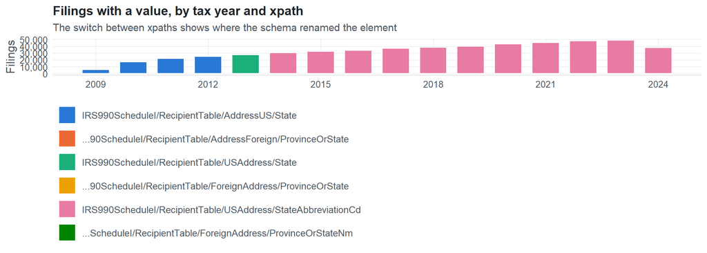

**Table view**

Table view: filings by tax year and series

| Tax year | IRS990ScheduleI/RecipientTable/AddressUS/State | …90ScheduleI/RecipientTable/AddressForeign/ProvinceOrState | IRS990ScheduleI/RecipientTable/USAddress/State | …90ScheduleI/RecipientTable/ForeignAddress/ProvinceOrState | IRS990ScheduleI/RecipientTable/USAddress/StateAbbreviationCd | …ScheduleI/RecipientTable/ForeignAddress/ProvinceOrStateNm |
| --- | --- | --- | --- | --- | --- | --- |
| 2009 | 5,375 | 5 | 0 | 0 | 0 | 0 |
| 2010 | 16,862 | 39 | 0 | 0 | 0 | 0 |
| 2011 | 21,884 | 44 | 0 | 0 | 0 | 0 |
| 2012 | 24,654 | 51 | 0 | 0 | 0 | 0 |
| 2013 | 0 | 0 | 27,474 | 71 | 0 | 0 |
| 2014 | 0 | 0 | 0 | 0 | 30,396 | 84 |
| 2015 | 0 | 0 | 0 | 0 | 32,477 | 75 |
| 2016 | 0 | 0 | 0 | 0 | 33,945 | 89 |
| 2017 | 0 | 0 | 0 | 0 | 36,928 | 111 |
| 2018 | 0 | 0 | 0 | 0 | 38,292 | 110 |
| 2019 | 0 | 0 | 0 | 0 | 39,702 | 96 |
| 2020 | 0 | 0 | 0 | 0 | 43,091 | 122 |
| 2021 | 0 | 0 | 0 | 0 | 44,833 | 153 |
| 2022 | 0 | 0 | 0 | 0 | 47,425 | 151 |
| 2023 | 0 | 0 | 0 | 0 | 48,715 | 144 |
| 2024 | 0 | 0 | 0 | 0 | 37,632 | 117 |

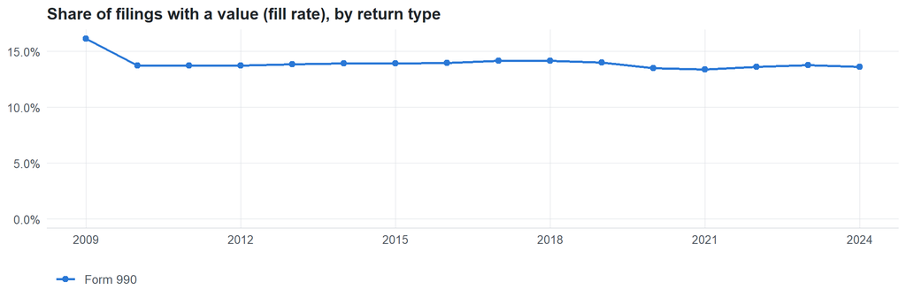

**Table view**

Table view: fill rate

| Tax year | Return type | Filings | All filings | Fill rate |
| --- | --- | --- | --- | --- |
| 2009 | Form 990 | 5,380 | 33,311 | 16.15% |
| 2010 | Form 990 | 16,901 | 123,025 | 13.74% |
| 2011 | Form 990 | 21,928 | 159,504 | 13.75% |
| 2012 | Form 990 | 24,705 | 179,688 | 13.75% |
| 2013 | Form 990 | 27,545 | 198,855 | 13.85% |
| 2014 | Form 990 | 30,480 | 218,619 | 13.94% |
| 2015 | Form 990 | 32,552 | 233,519 | 13.94% |
| 2016 | Form 990 | 34,034 | 243,903 | 13.95% |
| 2017 | Form 990 | 37,039 | 261,612 | 14.16% |
| 2018 | Form 990 | 38,402 | 271,442 | 14.15% |
| 2019 | Form 990 | 39,798 | 283,694 | 14.03% |
| 2020 | Form 990 | 43,213 | 320,342 | 13.49% |
| 2021 | Form 990 | 44,986 | 336,480 | 13.37% |
| 2022 | Form 990 | 47,576 | 349,055 | 13.63% |
| 2023 | Form 990 | 48,859 | 354,768 | 13.77% |
| 2024 | Form 990 | 37,749 | 277,298 | 13.61% |

## Repeating groups

Table cardinality in the concordance: **many**. 6 of 6 observed xpaths repeat within a filing.

Repeating element each xpath was observed in (from the raw indexed xpath)

| Xpath | Repeating element | Filings (summed over years) |
| --- | --- | --- |
| IRS990ScheduleI/RecipientTable/AddressForeign/ProvinceOrState | IRS990ScheduleI/RecipientTable | 119 |
| IRS990ScheduleI/RecipientTable/AddressUS/State | (none) | 32903 |
| IRS990ScheduleI/RecipientTable/AddressUS/State | IRS990ScheduleI/RecipientTable | 35872 |
| IRS990ScheduleI/RecipientTable/AddressForeign/ProvinceOrState | (none) | 20 |
| IRS990ScheduleI/RecipientTable/ForeignAddress/ProvinceOrState | (none) | 15 |
| IRS990ScheduleI/RecipientTable/ForeignAddress/ProvinceOrState | IRS990ScheduleI/RecipientTable | 56 |
| IRS990ScheduleI/RecipientTable/USAddress/State | (none) | 13507 |
| IRS990ScheduleI/RecipientTable/USAddress/State | IRS990ScheduleI/RecipientTable | 13967 |
| IRS990ScheduleI/RecipientTable/ForeignAddress/ProvinceOrStateNm | (none) | 177 |
| IRS990ScheduleI/RecipientTable/ForeignAddress/ProvinceOrStateNm | IRS990ScheduleI/RecipientTable | 1075 |
| IRS990ScheduleI/RecipientTable/USAddress/StateAbbreviationCd | (none) | 210459 |
| IRS990ScheduleI/RecipientTable/USAddress/StateAbbreviationCd | IRS990ScheduleI/RecipientTable | 222977 |

## Values

| Result | Check | Detail |
| --- | --- | --- |
| ▲ warn | Small code list | up to 187 distinct values per xpath and year |
| ✓ pass | Codes share one format | 100% have the shape AA |
| ✓ pass | Consistent letter case | 0.0% of values are lower case |

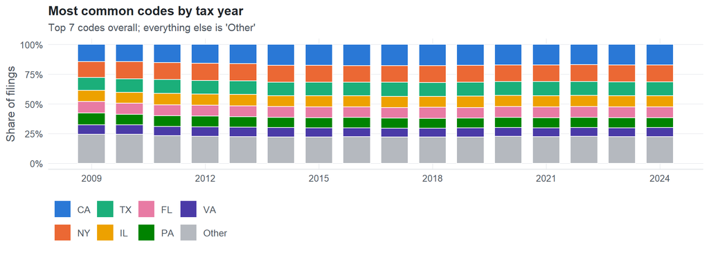

**Table view**

Table view: filings by code and tax year

| tax_year | CA | NY | TX | IL | FL | PA | VA | Other |
| --- | --- | --- | --- | --- | --- | --- | --- | --- |
| 2009 | 834 | 793 | 621 | 546 | 563 | 597 | 464 | 1,417 |
| 2010 | 2,367 | 2,401 | 1,910 | 1,490 | 1,521 | 1,493 | 1,310 | 4,021 |
| 2011 | 3,182 | 3,021 | 2,432 | 2,032 | 1,907 | 1,895 | 1,641 | 4,863 |
| 2012 | 3,731 | 3,401 | 2,633 | 2,218 | 2,149 | 2,122 | 1,850 | 5,327 |
| 2013 | 4,219 | 3,757 | 3,006 | 2,500 | 2,408 | 2,311 | 2,030 | 5,877 |
| 2014 | 5,199 | 4,163 | 3,311 | 2,759 | 2,639 | 2,561 | 2,294 | 6,534 |
| 2015 | 5,573 | 4,442 | 3,576 | 2,950 | 2,880 | 2,715 | 2,424 | 6,975 |
| 2016 | 5,852 | 4,629 | 3,750 | 3,072 | 2,936 | 2,823 | 2,497 | 7,358 |
| 2017 | 6,495 | 5,132 | 4,380 | 3,363 | 3,291 | 3,056 | 2,760 | 8,069 |
| 2018 | 6,716 | 5,377 | 4,378 | 3,489 | 3,487 | 3,116 | 2,834 | 8,367 |
| 2019 | 6,897 | 5,572 | 4,628 | 3,741 | 3,505 | 3,298 | 2,944 | 8,752 |
| 2020 | 7,439 | 6,069 | 5,032 | 4,037 | 3,904 | 3,667 | 3,205 | 9,777 |
| 2021 | 7,813 | 6,264 | 5,284 | 4,262 | 4,068 | 3,788 | 3,373 | 10,089 |
| 2022 | 8,222 | 6,772 | 5,691 | 4,542 | 4,424 | 4,082 | 3,597 | 10,879 |
| 2023 | 8,596 | 6,963 | 5,791 | 4,666 | 4,548 | 4,185 | 3,708 | 11,125 |
| 2024 | 6,592 | 5,350 | 4,496 | 3,531 | 3,464 | 3,099 | 2,901 | 8,531 |

Code frequencies (all xpaths, all years)

| Code | Filings | Share |
| --- | --- | --- |
| CA | 89,727 | 17.1% |
| NY | 74,106 | 14.1% |
| TX | 60,919 | 11.6% |
| IL | 49,198 | 9.4% |
| FL | 47,694 | 9.1% |
| PA | 44,808 | 8.5% |
| VA | 39,832 | 7.6% |
| DC | 39,444 | 7.5% |
| MA | 39,187 | 7.5% |
| OH | 38,389 | 7.3% |
| MD | 434 | 0.1% |
| ONTARIO | 147 | 0.0% |
| BC | 56 | 0.0% |
| Ontario | 36 | 0.0% |
| QUEBEC | 34 | 0.0% |
| PR | 20 | 0.0% |
| ALBERTA | 18 | 0.0% |
| LONDON | 16 | 0.0% |
| British Columbia | 14 | 0.0% |
| ON | 11 | 0.0% |
| SAN JUAN | 10 | 0.0% |
| JERUSALEM | 8 | 0.0% |
| Jerusalem | 7 | 0.0% |
| BRITISH COLUMBIA | 7 | 0.0% |
| Alberta | 6 | 0.0% |
| VANCOUVER | 6 | 0.0% |
| GUAYNABO | 6 | 0.0% |
| Quebec | 5 | 0.0% |
| San Juan | 5 | 0.0% |
| Guam | 4 | 0.0% |

First rows shown.

## Examples

| Tax year | Return | Xpath | Organization | Value | Source |
| --- | --- | --- | --- | --- | --- |
| 2024 | 990 | IRS990ScheduleI/RecipientTable/ForeignAddress/ProvinceOrStateNm | LMSARCOMA DIRECT RESEARCH FOUNDATION | Quebec | [XML](https://gt990datalake-rawdata.s3.amazonaws.com/EfileData/XmlFiles/202621009349300947_public.xml) |
| 2024 | 990 | IRS990ScheduleI/RecipientTable/USAddress/StateAbbreviationCd | Associated Colleges of Illinois Inc | IL | [XML](https://gt990datalake-rawdata.s3.amazonaws.com/EfileData/XmlFiles/202533189349311118_public.xml) |
| 2023 | 990 | IRS990ScheduleI/RecipientTable/ForeignAddress/ProvinceOrStateNm | Aarti for Girls Inc | Kadapa | [XML](https://gt990datalake-rawdata.s3.amazonaws.com/EfileData/XmlFiles/202412429349300936_public.xml) |
| 2023 | 990 | IRS990ScheduleI/RecipientTable/USAddress/StateAbbreviationCd | LC DANESE G BORLAND CHARITTRUST | DC | [XML](https://gt990datalake-rawdata.s3.amazonaws.com/EfileData/XmlFiles/202401089349300915_public.xml) |
| 2022 | 990 | IRS990ScheduleI/RecipientTable/ForeignAddress/ProvinceOrStateNm | Delmarva Education Association | Northern Island | [XML](https://gt990datalake-rawdata.s3.amazonaws.com/EfileData/XmlFiles/202333189349308653_public.xml) |
| 2022 | 990 | IRS990ScheduleI/RecipientTable/USAddress/StateAbbreviationCd | HOUSTON PRODUCERS’ FORUM | TX | [XML](https://gt990datalake-rawdata.s3.amazonaws.com/EfileData/XmlFiles/202321309349304417_public.xml) |
| 2021 | 990 | IRS990ScheduleI/RecipientTable/ForeignAddress/ProvinceOrStateNm | THE SOCIETY OF THE MISSIONARIES OF | Vinh City Nghe | [XML](https://gt990datalake-rawdata.s3.amazonaws.com/EfileData/XmlFiles/202213199349317426_public.xml) |
| 2021 | 990 | IRS990ScheduleI/RecipientTable/USAddress/StateAbbreviationCd | CAMP JOHN MARC FOUNDATION INC | TX | [XML](https://gt990datalake-rawdata.s3.amazonaws.com/EfileData/XmlFiles/202241039349300339_public.xml) |
| 2020 | 990 | IRS990ScheduleI/RecipientTable/ForeignAddress/ProvinceOrStateNm | MIES FOUNDATION INC | PR | [XML](https://gt990datalake-rawdata.s3.amazonaws.com/EfileData/XmlFiles/202240839349301524_public.xml) |
| 2020 | 990 | IRS990ScheduleI/RecipientTable/USAddress/StateAbbreviationCd | GREATER FARGO MOORHEAD ECONOMIC | ND | [XML](https://gt990datalake-rawdata.s3.amazonaws.com/EfileData/XmlFiles/202102679349301200_public.xml) |
| 2019 | 990 | IRS990ScheduleI/RecipientTable/ForeignAddress/ProvinceOrStateNm | SOCIETY OF URODYNAMICS & FEMALE | Calgary | [XML](https://gt990datalake-rawdata.s3.amazonaws.com/EfileData/XmlFiles/202041709349300204_public.xml) |
| 2019 | 990 | IRS990ScheduleI/RecipientTable/USAddress/StateAbbreviationCd | Knights of Columbus | NV | [XML](https://gt990datalake-rawdata.s3.amazonaws.com/EfileData/XmlFiles/202110719349300911_public.xml) |

## Reviewer checklist

- The definition matches the form line and instructions for every xpath’s schema years.
- Every xpath pooled here measures the same thing on the 990 and 990-EZ (close enough for analysis).
- The coverage chart has no unexplained gaps or jumps between tax years.
- Each open flag is fixed, or accepted with a note in validation_log.csv.
- Every code is valid for the list the form uses (state, country, valuation method, …).
- The code list and its meaning did not change across schema versions.
- Codes are stored as text, so values like leading zeros are preserved.

Record the review as a row in `inst/extdata/src/validation_log.csv` (variable_name, reviewer, date, status, note). Evidence built 2026-09-23 17:09:04 MST from the ef2 DuckDB builds (tax years 2009–2024).